# ColoGuide_Stage_II_local signature reporting file

#### Generated by [ReProMSig](https://omics.bjcancer.org/prognosis/) version 1.0

#### Date created: 2023-04-16

**Lead contact:** Jianmin Wu

**Email address:**

**Organization:** Peking University Cancer Hospital & Institute

### I. Signature summary

**Signature name:** ColoGuide_Stage_II_local

**Signature type:** Prognostic molecular signature

**Signature generation:**

- 738 candidate genes (user provided) were used in analysis
- Selection of robust candidates by a bootstrapping approach (200 iterations, occurrence > 45% frequency) using supervised principal components approach (SPCA)
- The final prediction model built by multivariate Cox regression

**Patient risk stratification:** 2 Groups

**Training & Validation datasets**

| Class | Dataset name | Primary site | Disease type | Molecular dataset | Endpoint | Pubmed | Clinical trial Registry |
| --- | --- | --- | --- | --- | --- | --- | --- |
| Training dataset | ProLT_stageII | Colorectal | Adenomas and Adenocarcinomas (96) | GSE30378 , GSE24550 (96 in total) | DFS (30 events, 96 patients) | 22991413 | NA |
| Validation dataset | ProLT_stageIII | Colorectal | Adenomas and Adenocarcinomas (76) | GSE30378 , GSE24550 (76 in total) | DFS (37 events, 76 patients) | 22991413 | NA |
| Validation dataset | ProV_stageII | Colorectal | Adenomas and Adenocarcinomas (108) | GSE14333 , GSE17538 (108 in total) | DFS (14 events, 108 patients) | 19996206 , 19914252 | NA |
| Validation dataset | ProV_stageIII | Colorectal | Adenomas and Adenocarcinomas (110) | GSE14333 , GSE17538 (110 in total) | DFS (37 events, 110 patients) | 19996206 , 19914252 | NA |

### II. Items of methods

#### Item 4. Source of data

##### Item 4a. Study design

**Training dataset**

- **Study design or source of data**

Sourced from 2 independent series of altogether 96 patients with stage II CRC.  
- 52 samples from GSE30378 were taken from patients treated surgically at different hospitals in the Oslo region, before adjuvant chemotherapy becoming standard treatment for stage III patients;  
- 44 samples from GSE24550 were consecutively collected from patients treated by curative resection at a Norwegian hospital (Aker University Hospital, Oslo, Norway).

**Validation dataset(s)**

- **Study design or source of data**

**ProLT_stageIII:** sourced from 2 independent series of altogether 76 patients with stage III CRC.  
- 43 samples from GSE30378 were taken from patients treated surgically at different hospitals in the Oslo region, before adjuvant chemotherapy becoming standard treatment for stage III patients;  
- 33 samples from GSE24550 were consecutively collected from patients treated by curative resection at a Norwegian hospital (Aker University Hospital, Oslo, Norway).  
**ProV_stageII:** sourced from 2 independent series of altogether 108 patients with stage II CRC.  
- Consecutive patients from GSE14333 (n = 94) were retrieved from the tissue banks of the Royal Melbourne Hospital and the H. Lee Moffitt Cancer Center in the United States.  
- Patients from GSE17538 (n = 14) were treated at the Vanderbilt Medical Centre (Nashville, TN, USA).  
**ProV_stageIII:** sourced from 2 independent series of altogether 110 patients with stage III CRC.  
- Consecutive patients from GSE14333 (n = 91) were retrieved from the tissue banks of the Royal Melbourne Hospital and the H. Lee Moffitt Cancer Center in the United States.  
- Patients from GSE17538 (n = 19) were treated at the Vanderbilt Medical Centre (Nashville, TN, USA).

##### Item 4b. Key study dates

**Training dataset**

52 patients from GSE30378 were recruited from 1987 to 1989, and 44 patients from GSE24550 were recruited from 2005 to 2008.

**Validation dataset(s)**

**ProLT_stageIII:** 43 patients from GSE30378 were recruited from 1987 to 1989, and 33 patients from GSE24550 were recruited from 2005 to 2008.  
**ProV_stageII:** Not mentioned in this dataset.  
**ProV_stageIII:** Not mentioned in this dataset.

#### Item 5. Participants

##### Item 5a. Key study setting

**Training dataset**

- **Study setting, number and location of centers**

- 52 patients were collected from hospitals in the Oslo region.  
- 44 patients were consecutively collected at Oslo University Hospital, Aker, Norway.

**Validation dataset(s)**

- **Study setting, number and location of centers**

ProLT_stageIII:  
- 43 patients were collected from hospitals in the Oslo region.  
- 33 patients were consecutively collected at Oslo University Hospital, Aker, Norway.  
ProV_stageII: Patients were collected at H Lee Moffitt Cancer Center, Royal Melbourne Hospital, and Vanderbilt University Medical Center.  
ProV_stageIII: Same as the ProV_stageII dataset.

##### Item 5b. Eligibility criteria for participants

**Training dataset**

- **Exclusion criteria**

**Clinical anlaysis**

Patients with stage III tumors were excluded.

**Statistical anlaysis**

No patients were excluded by ReProMSig.

- **Inclusion criteria**

**Clinical anlaysis**

Patients with stage II tumors were selected.

**Statistical anlaysis**

All patients were included in ReProMSig.

**Validation dataset(s)**

- **Exclusion criteria**

**Clinical anlaysis**

**ProLT_stageIII:** Patients with stage II tumors were excluded.  
**ProV_stageII:** Patients with stage III tumors were excluded. Individuals from GSE14333 series who had received preoperative chemotherapy and/or radiotherapy or for whom tumor-derived total RNA was inadequate for microarray analysis (RNA integrity number [RIN] < 6) were excluded.  
**ProV_stageIII:** Patients with stage II tumors were excluded. Individuals from GSE14333 series who had received preoperative chemotherapy and/or radiotherapy or for whom tumor-derived total RNA was inadequate for microarray analysis (RNA integrity number [RIN] < 6) were excluded.

**Statistical anlaysis**

**ProLT_stageIII:** No patients were excluded by ReProMSig.  
**ProV_stageII:** No patients were excluded by ReProMSig.  
**ProV_stageIII:** No patients were excluded by ReProMSig.

- **Inclusion criteria**

**Clinical anlaysis**

**ProLT_stageIII:** Stage III patients were selected.  
**ProV_stageII:** Nonoverlapping stage II patients between GSE14333 and GSE17538 series were included.  
**ProV_stageIII:** Nonoverlapping stage III patients between GSE14333 and GSE17538 series were included.

**Statistical anlaysis**

**ProLT_stageIII:** All patients were included in ReProMSig.  
**ProV_stageII:** All patients were included in ReProMSig.  
**ProV_stageIII:** All patients were included in ReProMSig.

- **Is it similar to the eligibility criteria used in training dataset**

Similar as aforementioned.

##### Item 5c. Received treatments

**Training dataset**

- **Treatment details**

- Patients from GSE30378 series had not received adjuvant chemotherapy, which was introduced as standard treatment for patients with stage III CRC aged <75 years in Norway in 1997. - Patients from GSE24550 had not received preoperative radiotherapy and adjuvant chemotherapy was given in accordance with Norwegian guidelines to patients with stage III colon cancer aged <75 years, or to patients with stage II disease in whom <8 lymph nodes were examined, or to patients with preoperative or intraoperative tumour perforation. Furthermore, adjuvant chemotherapy is generally only given to physically fit patients, but not to patients with rectal cancer. All underwent curative resection and no bowel perforation was reported.

**Validation dataset(s)**

- **Treatment details**

**ProLT_stageIII:** Same as the training dataset.  
ProV_stageII:  
- Patients from GSE14333 series had not received preoperative chemotherapy and/or radiotherapy. Nine patients had received postoperative concurrent chemoradiotherapy (50.4 Gy in 28 fractions with concurrent 5-fluorouracil), 13 patients had only received adjuvant chemotherapy.  
- 14 patients from GSE17538 had no available information about received treatments.  
ProV_stageIII:  
- Patients from GSE14333 series had not received preoperative chemotherapy and/or radiotherapy. 12 patients had received postoperative concurrent chemoradiotherapy (50.4 Gy in 28 fractions with concurrent 5-fluorouracil), one patient had only received adjuvant radiotherapy, 51 patients had only received adjuvant chemotherapy (either single agent 5-fluouracil/capecitabine or 5-fluouracil and oxaliplatin).  
- 19 patients from GSE17538 series had no available information about received treatments.

#### Item 6. Outcome

##### Item 6a. Clinical endpoints being analyzed

- **Outcome**

Relapse or death from colorectal cancer was regarded as events, and patients with no events were censored. Specially, 10 years follow-up was done for the GSE30378 dataset, and 5 years follow-up was done for the GSE24550 dataset.

- **How and when assessed**

Not mentioned in this study.

##### Item 6b. Actions for blind assessment of the outcome

Not mentioned in this study.

#### Item 7. Predictors

##### Item 7a. Predictors used in developing the multivariable prediction model

Genome-wide expression at the exon-level for colorectal cancer tissue biopsies was analyzed using the Affymetrix Human Exon 1.0 ST platform.

##### Item 7b. Actions for blind assessment of predictors

Not mentioned in this study.

#### Item 8. Sample Size

- **How the study size arrived at**

Not mentioned in this study.

#### Item 9. Missing Data

**Training dataset**

- **Missing value handling**

Assuming occurrence of missing values in genes were random events, KNN method (impute.knn function in R package impute version 1.60.0) was applied to impute missing values by ReProMSig. Patients with missing outcome or with >=10% missing clinicopathological variables, were excluded from ReProMSig analysis.

**Validation dataset(s)**

- **Missing value handling**

Assuming occurrence of missing values in genes profiles were random events, KNN method (impute.knn function in R package impute version 1.60.0) was applied to impute missing values by ReProMSig.  
Patients with missing outcome or with >=10% missing clinicopathological variables, were excluded from ReProMSig analysis.

#### Item 10. Statistical Analysis Methods

##### Item 10a. Predictors handling method

- **Molecular profiles**

Expression values were converted to log2 transformed.

- **Implausible observations**

Extreme values (e.g., outliers) in expression profiles were regarded as NA, and imputed by KNN method, using impute.knn function in R package "impute " (version 1.60.0).

##### Item 10b. Model building procedures

- **Predictor selection before modeling**

A bootstrapping procedure was applied to select molecular predictors associated with outcome from the list of candidate predictors shown above. For each bootstrap resample (samples were drawn with replacement keeping the same size as the original training dataset), supervised principal components approach (SPCA, R package "SPCA") was applied. The entire process was repeated 200 times, and predictors with frequency of more than 45% occurrence were taken as potential signature predictors for prognosis.

- **Multivariable prediction model building**

Univariate Cox regression model (R package "survival") was ﬁtted to the expression data (training dataset) of the selected molecular predictors, to identify robust molecular signatures (using 0.05 as the significance level) associated with DFS, which were used to generate the multivariable prediction signature (R package "survival").

- **Collinearity assessment**

The correlations between each pair of selected molecular predictors were estimated using Pearson correlation analysis, to evaluate the presence of collinearity. However, we did not exclude any predictors even if potential collinearity found.

#### Item 10c. Prediction method for the validation dataset(s)

- **Signature model**

Individual signature score was calculated by a weighted sum of the predictors in the generated multivariate Cox regression model, in which weights are the corresponding regression coefficients (i.e., log hazard ratios). The signature score for a patient is the log relative hazard compared with a hypothetical patient whose signature score is zero.

- **Nomogram**

Nomogram was not constructed as no clinicopathological variable was selected in the development form.

- **Online research tool**

An online research tool for single patient prediction of risk score (i.e., the exponential of signature score) and DFS probabilities at 12, 36, 60-months using the molecular signature is available from https://omics.bjcancer.org/prognosis/.

##### Item 10d. Model performance assessment

- **Independence test**

Univariate and multivariate Cox regression analyses were performed to test whether individual prognosis factor is an independent factor in predicting patients DFS. Both the molecular signature prediction (risk groups) and clinicopathological variable (MSI_status) were included in the independence test.

- **Interaction test**

We did not examine interaction terms but relied on the main effects of the selected.

- **Kaplan-Meier analysis**

Discrimination is visually inspected from the spread of Kaplan-Meier curves for each predicted risk group (high-risk, and low-risk), in the training and validation datasets respectively. Differences in the probability of DFS between risk groups (high risk vs low risk) were tested by the two-sided log-rank test. In addition, Kaplan-Meier plots also presented the total number of patients, the number of events (outcome) for each risk group.

- **Time dependent receiver operating characteristic (ROC) analysis**

12, 36, 60-months time-dependent ROC analysis was performed to examine the prognostic accuracy of the developed model in the training dataset. ROC curves for molecular signature was plotted. An area under the ROC curve (AUC) of 0.5 indicates no discrimination, whereas an AUC of 1.0 indicates perfect discrimination.

- **Prediction error (PE) curve analysis**

PE curve analysis was applied in the training dataset to examine the prognosis prediction error rate, and ten-fold cross-validation cumulative prediction error was computed using Kaplan-Meier estimation as reference. Models with smaller area under the curve indicates a relatively lower error rate. PE curves for molecular signature was plotted.

- **Calibration plots**

The calibration plots at 12, 36, 60-months were used to assess the consistency between the actual and predicted DFS probabilities from the molecular signature in training dataset.

- **DFS**

DFS with 95% confidence intervals at 12, 36, 60-months in the training and validation datasets respectively, were calculated by Kaplan-Meier method for patients in each risk group.

- **Association analysis**

To assess whether the developed prediction model is correlated with clinicopathological variables, two-sided Fisher's exact test (for categorical variables) and two-sided t test (for continuous variables) were applied to measure association or difference between predicted risk groups.

#### Item 11. Risk Groups

Patients were stratified into two risk groups on the basis of signature score distribution in each dataset: low-risk (signature score < 0.904) and high-risk (signature score >= 0.904).

#### Item 12. Development vs. Validation

**Differences in development and validation**

**Setting**

The details are described at Item 5a.

**Eligibility criteria**

The details are described at Item 5b.

**Outcome**

The details are described at Item 6.

**Predictors**

The mRNA expression profiles of predictors in training dataset and ProLT_stageIII dataset were generated using Affymetrix Human Exon 1.0 ST platform, while those in ProV_stageII and ProV_stageIII dataset were determined using Affymetrix Human Genome U133Plus 2.0 arrays.

### III. Items of results

#### Item 13. Participants

##### Item 13a. Study participants

**Training dataset**

In the training dataset, 96 out of 96 (100%) had follow-up of DFS with a median follow-up (by reverse Kaplan-Meier method) of **59.64** months (range: **5.04-120**).

**Validation dataset(s)**

**ProLT_stageIII:** 76 out of 76 (100%) had follow-up of DFS with a median follow-up (by reverse Kaplan-Meier method) of **56.04** months (range: **2.04-120**).  
**ProV_stageII:** 108 out of 108 (100%) had follow-up of DFS with a median follow-up (by reverse Kaplan-Meier method) of **44.8** months (range: **0.43-118.58**).  
**ProV_stageIII:** 110 out of 110 (100%) had follow-up of DFS with a median follow-up (by reverse Kaplan-Meier method) of **52.86** months (range: **0.49-112.33**).

##### Item 13b/c. Comparison of participant characteristics between the training and validation datasets

**Clinical and pathological characteristics**

[interactive table not shown]

Key clinical and pathological characteristics of participants were included. P denotes the P value of the characteristics distribution comparison between the training dataset and each validation dataset. Categorical variables were compared using fisher'exact test, and continuous variables using t-test.

**Expression profile distribution**

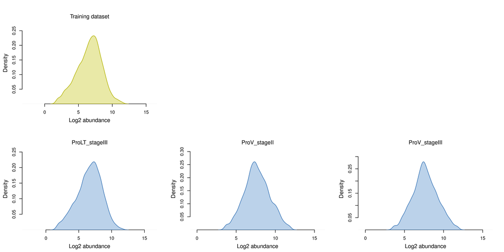

The density plots present the distributions of the log2-transformed expression level for the training dataset ProLT_stageII, and the validation datasets ProLT_stageIII, ProV_stageII, ProV_stageIII.

#### Item 14. Model Development

**Unadjusted association between each candidate predictor and outcome in the training dataset**

| Gene symbol | Hazard Ratio (95% CI) | P |
| --- | --- | --- |
| WNT11 | 1.971 (1.33-2.92) | 7.20e-04 |
| DNASE1 | 1.874 (1.292-2.718) | 9.30e-04 |
| AVL9 | 4.462 (1.813-10.984) | 1.10e-03 |
| STAU1 | 2.926 (1.507-5.681) | 1.50e-03 |
| DKK1 | 1.65 (1.209-2.251) | 1.60e-03 |
| RPL10 | 3.052 (1.465-6.359) | 2.90e-03 |
| ANXA9 | 2.125 (1.28-3.528) | 3.60e-03 |
| CMTM7 | 2.648 (1.371-5.118) | 3.80e-03 |
| DNTTIP1 | 2.184 (1.286-3.707) | 3.80e-03 |
| RHCG | 2.251 (1.299-3.904) | 3.80e-03 |

[output cut: 90 more lines]

Unadjusted association between top 100 candidate predictors and DFS.

**TRIPOD relevance:** This table reports the information needed suggested by Item 14a "Number of participants and outcome events involved in model development" and Item 14b "Unadjusted association between each candidate predictor and outcome".

#### Item 15. Model Speciﬁcation

##### Item 15a. Details of the prediction model

**Signature genes and the corresponding coefficients**

| Gene symbol | Coefficient | HR (95% CI) | P |
| --- | --- | --- | --- |
| CCL19 | 0.052 | 0.637 (0.453-0.897) | 9.9e-03 |
| CHN2 | 0.541 | 1.555 (1.151-2.1) | 4.0e-03 |
| CR2 | -0.865 | 0.526 (0.332-0.834) | 6.3e-03 |
| DKK1 | 0.607 | 1.65 (1.209-2.251) | 1.6e-03 |
| GNG4 | 0.071 | 1.445 (1.118-1.867) | 4.9e-03 |
| GREM1 | -0.335 | 0.791 (0.654-0.957) | 0.016 |
| HAS2 | 0.2 | 1.441 (1.11-1.871) | 6.0e-03 |
| SEMA3A | 0.009 | 1.47 (1.125-1.92) | 4.7e-03 |
| WNT11 | 0.472 | 1.971 (1.33-2.92) | 7.2e-04 |

9 variables comprising the developed signature and their corresponding coefficients were calculated by the Cox regression model.  
The **signature score** of a patient can be calculated using the following formula:  
Signature score = 0.052***CCL19** + 0.541***CHN2** - 0.865***CR2** + 0.607***DKK1** + 0.071***GNG4** - 0.335***GREM1** + 0.2***HAS2** + 0.009***SEMA3A** + 0.472***WNT11**.  
A higher signature score indicates a relative poorer prognosis.

**Pearson correlation plot for pairwise expression comparison among signature genes**

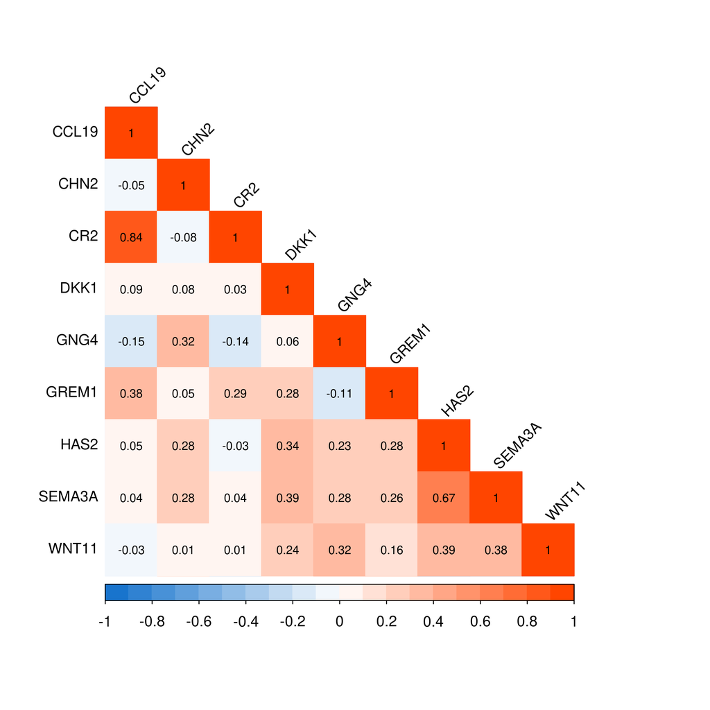

The correlation plot shows the Pearson correlation coefficients of expression profiles between each pair of signature predictors in the training dataset. From the plot, the correlation pattern of signature predictors can be visually checked if their expression levels are independent. The correlation coefficient ranges from -1 to 1. A smaller absolute value implies that a lower linear dependency, indicating this pair of signature predictors maybe is independent.

##### Item 15b. Application of the prediction model

Nomogram was not constructed as no clinicopathological variable was selected in the development form.

#### Item 16. Model Performance

**Cox regression analysis of signature and clinicopathological variables (training dataset)**

[interactive table not shown]

Univariate hazard ratio and multivariate hazard ratio of each variable with a 95% confidence interval provided in parentheses, indicate multiplicative effects on the hazard. P denotes the statistical significances in the hazard ratio between a test group relative to a reference group, which were tested by the wald test. For multivariate Cox analysis, the relationship between the variable of interest and the outcome was evaluated after adjusting for potential confounding variables that may be related to the outcome.

**Receiver operating characteristic (ROC) analysis (training dataset)**

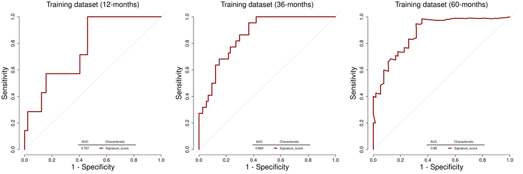

Time-dependent receiver operating characteristic (ROC) curves show the sensitivity and specificity of different variables in prognosis prediction. It could help to quantify and compare the discrimination ability of the signature and clinicopathological prognosis factors using the 12, 36, 60-months time-dependent ROC analysis in the training dataset. The area under the curve (AUC) ranges from 0.5 (no discrimination) to a theoretical maximum of 1, which were texted in the legend for each prognosis model. A prognosis model with larger AUC indicates a better performance.

**Calibration of the molecular signature (training dataset)**

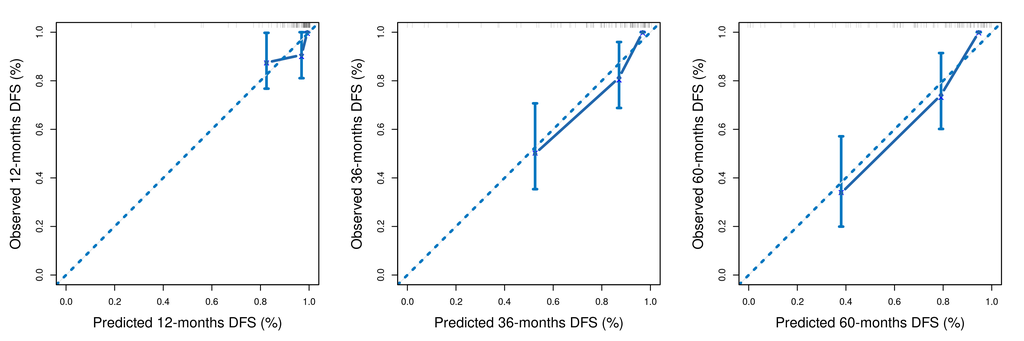

Calibration plots at 12, 36, 60-months were generated to explore the performance of the signature. Signature-predicted probabilities and observed outcome were plotted on the X-axis and Y-axis, respectively. A calibration plot along the 45-degree line indicates perfect consistency between the actual and signature-predicted prognosis. The vertical bars represent 95% CIs.

**Prediction error (PE) curve analysis (training dataset)**

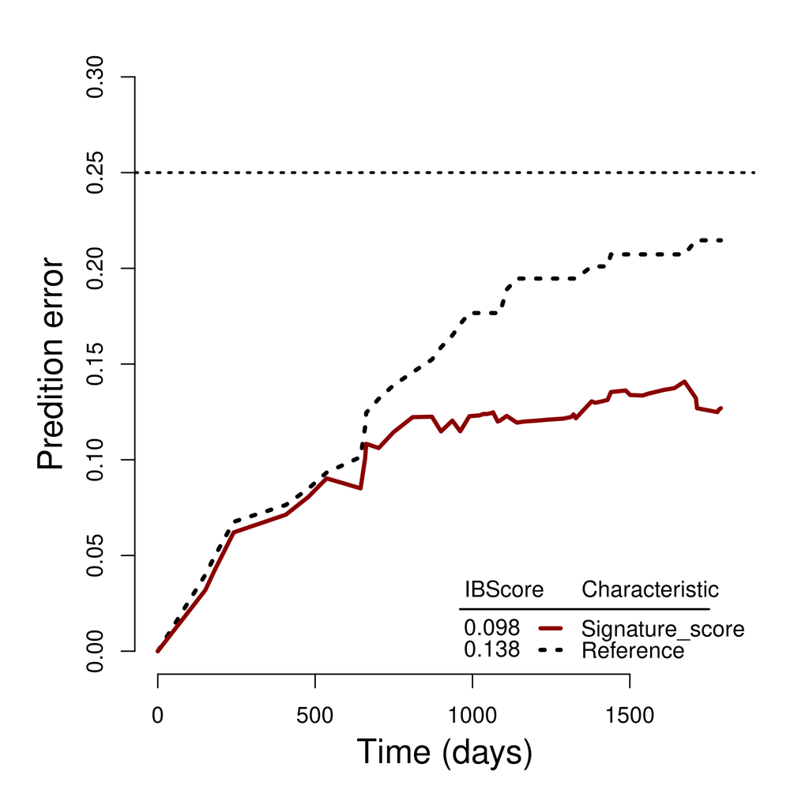

Prediction error (PE) curves were used to evaluate the performance of prediction models in the training dataset, and ten-fold cross-validation cumulative prediction error were computed using Kaplan-Meier estimation as reference. Integrated Brier score (IBScore) was defined as the area under a prediction error curve, which were texted in the legend for each prognosis model. A prognosis model with smaller IBScore indicates a better performance.

**Association analysis of signature-predicted risk groups with clinicopathological variables**

[interactive table not shown]

Association analysis was employed to investigate whether the signature is correlated with clinicopathological variables and other molecular features in both training and validation dataset. Samples with valid values (such as non-missing, non-unknown) were compared in the analysis. P denotes the P values comparing the associations between the clinicopathological/molecular variables and the risk groups in each dataset. Fisher'exact test was used for association analysis.  
ProV_stageII, ProV_stageIII datasets were not shown due to lack of MSI_status variable.

**Kaplan-Meier analysis of signature-predicted risk groups**

###### Training dataset

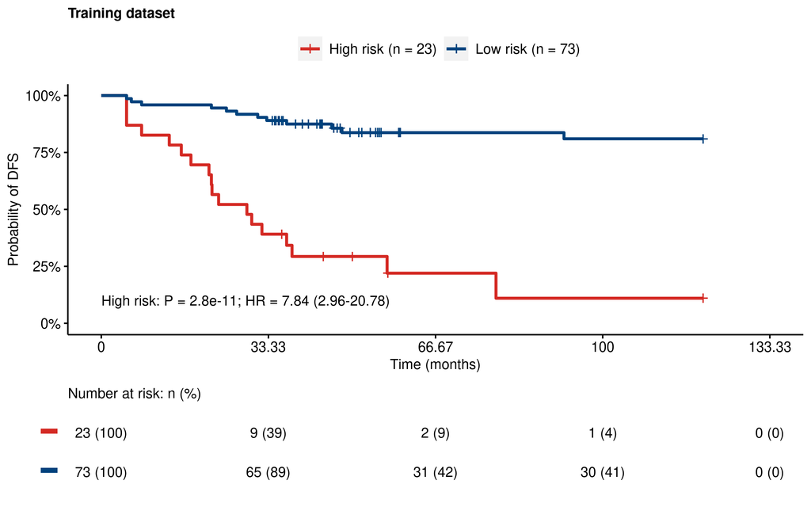

###### Validation dataset 1

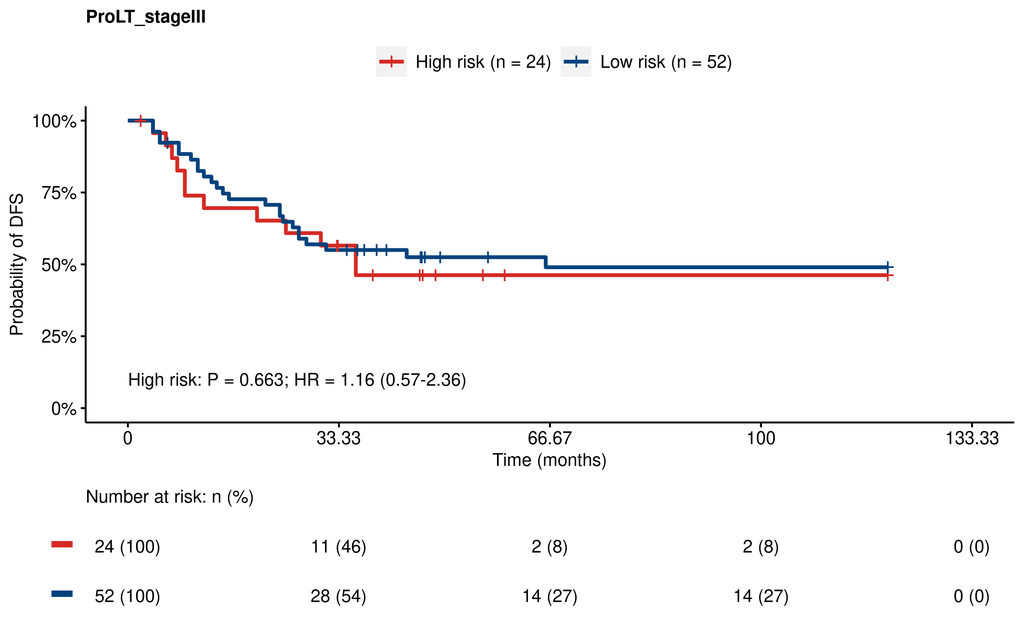

###### Validation dataset 2

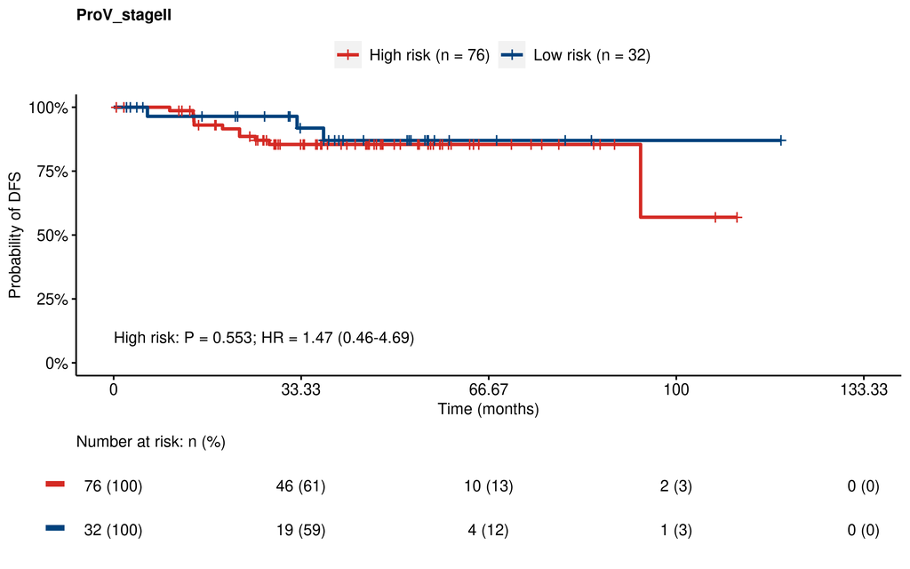

###### Validation dataset 3

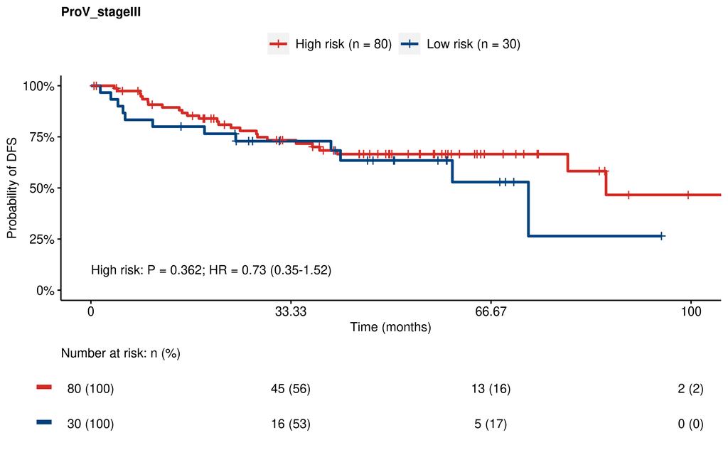

Kaplan-Meier survival curves for DFS in training and validation datasets, stratified by the prediction model (high-risk and low risk). The performance of the prognostic signature was evaluated by the two‐sided log‐rank test in both training dataset and validation datasets. P < 0.05 was considered as statistically significant, and 95% confidence intervals are presented in brackets. HR, hazard ratio.

**12/36/60 months DFS for different signature-predicted risk groups**

[interactive table not shown]

12/36/60 months DFS of patients in different risk groups for each dataset were predicted by the prediction model.